Regional Clarity RS Model · v2

# Secchi depth from Landsat: shoreline proximity + systemic gap-aware tuning

A second pass over the same 6-state Mountain West Secchi-depth (SDD) pipeline, closing out the two threads deferred at the end of the v1 report: gap-aware hyperparameter selection applied at every tuning step (not just the final one), and the siteSR pipeline's shoreline-proximity flag added as a candidate model feature. Same training data, same outlier-filtering methodology, same three architectures (XGBoost, LightGBM, a feedforward neural net), same spatial holdout CV - built in a separate folder so the two runs stay directly, apples-to-apples comparable.

Branch: `outlier-removal-rework` Compares against: `outlier_rework` (v1) Target: Secchi disk depth (m) Region: 6-state Mountain West, HUC4-partitioned

New feature shoreline_flag survives elimination in all 3 models

Final production (XGBoost) 1.839 m test RMSE, vs. 1.860 m in v1

Intersection feature set 16 features 1-for-1 swap vs. v1's 16

Gap-aware tuning 4 stages was 1 of 4 in v1

What changed vs. v1

## Same pipeline, two additions, one new folder

Everything upstream of feature-group modeling is byte-for-byte identical to v1: the same 12,637 field–satellite matchups, the same four-stage outlier-filtering methodology (site geometry, metadata/cloud QA, reflectance-outlier RANSAC, heavy-rain gap filter), the same gridMET antecedent-weather summaries, and the same LakeCat catchment characteristics. Those outputs were copied into `outlier_rework_v2/` rather than regenerated, so this folder works standalone even if `outlier_rework/` is later removed - nothing here re-hits gridMET, LakeCat, or the elevation API.

Two things changed, both requested as follow-ups at the end of the v1 report:

1. **Shoreline-proximity flag added as a model feature.** The siteSR pipeline already computes a per-site distance to its matched waterbody's shoreline, thresholded into a QA flag - it was sitting unused in a CSV v1's own site-characteristics script already read, just not selected. See Feature engineering, below, for the exact definition and encoding.
2. **Gap-aware hyperparameter selection extended to every tuning step.** v1 only used gap-aware selection (pick the smallest train-val gap among trials within 2% of the best CV RMSE, instead of the single lowest-RMSE trial) at the very last tuning step. The single-model baseline, the feature-group ablation, and by extension the fixed hyperparameters backward elimination reuses were all still on the plain, gap-blind objective. v1 flagged this as the same failure mode its final-tuning fix was built to address, present at every earlier stage.

A third piece of technical debt got fixed along the way, not requested but necessary to add a feature safely: v1 hardcoded its selected 16-feature set as a copy-pasted Python literal in three separate files, with no code path connecting it back to backward elimination's actual output. v2's backward elimination now writes `results/selected_features.json` once, and every downstream script reads it - the kind of drift risk that matters most exactly when the feature set is changing.

Feature engineering

## Site characteristics: 7 candidates → 8

The optical (17) and antecedent-weather (20) candidate feature groups are unchanged from v1. One feature was added to the site-characteristics group:

| Feature | Definition | Source |
| --- | --- | --- |
| elevation_m | site elevation | USGS 3DEP, via elevatr |
| catchment_area_sqkm, pct_impervious_2006, pct_urban_2006, pct_forest_2006, pct_cropland_2006, pct_wetland_2006 | catchment land cover, 2006 vintage | LakeCat (StreamCatTools) |
| **shoreline_flag** (new) | 0 = open water, 1 = near-shore (≤230m optical-pixel buffer), 2 = site falls outside its matched waterbody polygon | siteSR pipeline's `dist_to_shore`/`flag_optical_shoreline`/`flag_wb`, already computed for QA but never previously consumed downstream |

The underlying `dist_to_shore` value (continuous, meters) was collapsed to this 3-level integer category rather than passed through directly, so the ~4% of sites (62 of 1,525) that fall outside their matched waterbody polygon - and would otherwise be missing outright, since distance-to-shore is undefined for them - get an explicit third category instead of a gap. Across the 1,525 sites in the training population: 629 open water, 834 near-shore, 62 outside their waterbody. It is treated as an ordinary integer feature (fed to correlation pruning and both tree models and the neural net the same way `atm_corr_LaSRC` already is), not one-hot encoded - consistent with how the pipeline already handles its other binary/categorical inputs.

Feature group comparison

## Site characteristics still earn their keep, with one more candidate in the pool

Same four-group comparison as v1 (optical / +site / +weather / +both), same correlation pruning, now gap-aware-tuned at this stage too instead of plain best-CV-RMSE:

| Model | Feature group | Features | RMSE | R² | Bias |
| --- | --- | --- | --- | --- | --- |
| XGBoost | optical | 13 | 1.854 | 0.441 | –0.029 |
|  | + site | 21 | 1.836 | 0.472 | 0.318 |
|  | + weather | 26 | 1.841 | 0.448 | –0.041 |
|  | + both | 34 | 1.805 | 0.484 | 0.283 |
| LightGBM | optical | 13 | 1.848 | 0.442 | –0.030 |
|  | + site | 21 | 1.835 | 0.470 | 0.286 |
|  | + weather | 26 | 1.838 | 0.448 | –0.039 |
|  | + both | 34 | 1.796 | 0.489 | 0.272 |
| Neural net | optical | 13 | 1.856 | 0.468 | –0.309 |
|  | + site | 21 | 1.865 | 0.451 | 0.311 |
|  | + weather | 26 | 1.944 | 0.445 | –0.392 |
|  | + both | 34 | 1.833 | 0.452 | –0.032 |

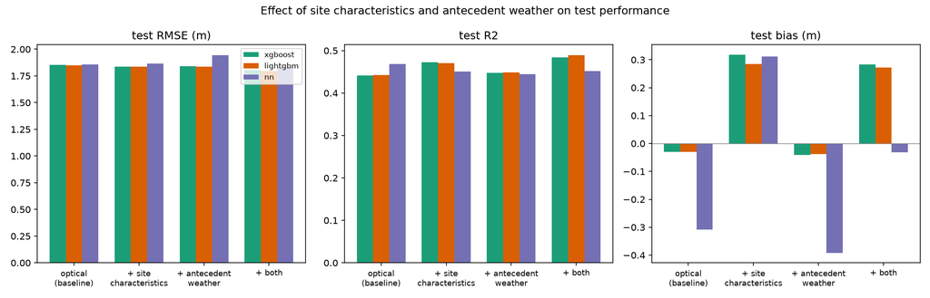

Test RMSE by feature group, all three models (v2 data).

SHAP attribution

## Optical still dominates; site's share grows with the new feature

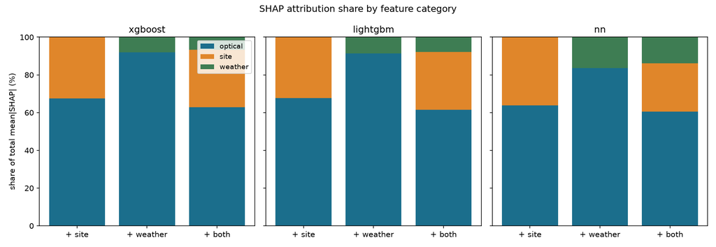

Share of total mean |SHAP| attribution by feature category, v2 (includes shoreline_flag in "site").

| Model | Feature group | Optical | Site | Weather |
| --- | --- | --- | --- | --- |
| XGBoost | optical + site | 67.5% | 32.5% | — |
|  | optical + site + weather | 62.9% | 30.3% | 6.8% |
| LightGBM | optical + site | 67.7% | 32.3% | — |
|  | optical + site + weather | 61.6% | 30.6% | 7.8% |
| Neural net | optical + site | 63.9% | 36.1% | — |
|  | optical + site + weather | 60.6% | 25.6% | 13.8% |

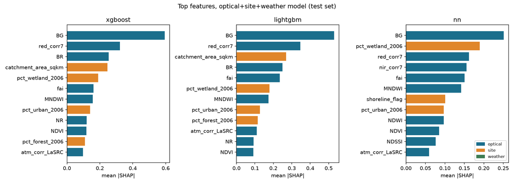

Top 12 features by mean |SHAP|, optical+site+weather model, v2. Compare against v1's equivalent figure: BG remains the top feature for every architecture.

Backward feature elimination

## shoreline_flag survives in all three independent eliminations

Same cross-fold-consensus elimination as v1 (shadow-decoy stopping, 3-seed-averaged importance, hyperparameters held fixed at each model's gap-aware-tuned optical+site+weather config), run on the correlation-pruned candidate pool that now includes `shoreline_flag`:

[output not shown]

A rare feature that survives on its own merit in every model

`shoreline_flag` is not eliminated in any of the three independent per-model eliminations, nor in the joint elimination - it clears the shadow-permutation noise floor for XGBoost, LightGBM, and the neural net alike. Very few candidates in this pipeline have cleared that bar this consistently; most of what gets added to this feature set (see v1's antecedent-weather variables) survives for at most one or two architectures.

### Shared feature set: a one-for-one swap

The same two ways of building a cross-model-shared set were compared: joint elimination (co-optimized across all three models) and the plain intersection of the three independent results.

|  | v1 intersection (16) | v2 intersection (16) |
| --- | --- | --- |
| Optical (11) | atm_corr_LaSRC, red_corr7, nir_corr7, temp_corr7, BG, NR, fai, NDVI, NDSSI, NDWI, MNDWI | identical |
| Site (5→5) | catchment_area_sqkm, pct_urban_2006, pct_forest_2006, pct_cropland_2006, pct_wetland_2006 | catchment_area_sqkm → shoreline_flag |
| Weather (0) | — | — |

The v2 intersection set is the same size (16 features) as v1's, and differs by exactly one substitution: `catchment_area_sqkm` drops out, `shoreline_flag` takes its place. Everything else - all 11 optical features, the other 4 site variables, and weather's complete absence - is identical to v1. **The 16-feature intersection (with shoreline_flag) is the feature set used for final tuning and evaluation below**, matching v1's own precedent of using the intersection rather than the joint set.

The joint set (21 features, co-optimized across all three models) also keeps `shoreline_flag` and additionally keeps `catchment_area_sqkm`, `pct_impervious_2006`, `swir1_corr7`, `BR`, and `tmax_degC_prev30` - the one antecedent-weather variable to survive anywhere in this round, versus none surviving in v1's joint set.

Gap-aware tuning & final evaluation

## Gap-aware from the start: a smaller mean gap for two of three models, and a better final test result for two of three

Final hyperparameter search on the 16-feature intersection set (with shoreline_flag), same gap-aware selection rule as v1 (pick the smallest train-val gap among trials within 2% of the best CV RMSE):

| Model | Chosen val RMSE | Chosen gap | Pure-best val RMSE would have been | Trials in tolerance band |
| --- | --- | --- | --- | --- |
| XGBoost | 1.465 | 0.342 | 1.458 | 37 / 40 |
| LightGBM | 1.470 | 0.399 | 1.453 | 30 / 40 |
| Neural net | 1.484 | 0.009 | 1.466 | 4 / 15 |

### Mean train-val gap, before vs. after applying gap-aware tuning throughout the pipeline

| Model | v1 mean gap (gap-aware only at final step) | v2 mean gap (gap-aware throughout) | Partition 3 gap (hardest fold) |
| --- | --- | --- | --- |
| XGBoost | 0.375 | 0.342 | 0.855 → 0.848 |
| LightGBM | 0.393 | 0.399 | 1.007 → 0.871 |
| Neural net | 0.052 | 0.009 | 0.550 → 0.625 |

Applying gap-aware selection at the baseline and feature-group stages too - not just at this final step - modestly shrinks the average train-val gap for XGBoost and, more sharply, for the neural net; it's essentially flat for LightGBM. Partition 3 remains the largest single-fold gap for every model regardless, exactly as v1 found - consistent with the outlier-HUC investigation's separate conclusion that partition 3's difficulty is a physical signal-compression property of its HUC4 1701 lake cluster, not a tuning-objective artifact. Gap-aware tuning was never expected to close that gap on its own; it was designed to stop the tuner from actively making the average gap worse, and on that narrower claim it holds up for two of the three architectures.

### Final production configuration

Feature set: the 16-feature intersection (with shoreline_flag). Hyperparameters: gap-aware-tuned, now consistently so from the baseline stage onward. SDD-weighting (k=2.0): applied for XGBoost and LightGBM, not for the neural net - same established finding as v1.

| Model | CV RMSE | Test RMSE | Test R² | Test Bias |
| --- | --- | --- | --- | --- |
| XGBoost | 1.499 | 1.839 | 0.466 | +0.313 |
| LightGBM | 1.496 | 1.815 | 0.474 | +0.241 |
| Neural net | 1.519 | 1.888 | 0.434 | –0.297 |

Both tree models improve on v1's final production result

XGBoost's test RMSE improves from 1.860m (v1) to 1.839m; LightGBM improves from 1.830m to 1.815m. Bias improves for both as well (XGBoost +0.409→+0.313, LightGBM +0.314→+0.241) - less over-prediction of clarity than v1's final config. Neither change is large, and CV RMSE is very slightly worse for both (v1's final tuning had already benefited from a feature-group stage that happened to pick unusually low-RMSE hyperparameters, which this stage's gap-aware objective trades away on purpose) - but the number that matters most, the one held-out look at test, moved in the right direction for exactly the two models where gap-aware-throughout tuning was supposed to help without a capacity ceiling getting in the way.

The neural net is worse in this version

The neural net's test RMSE moves from 1.839m (v1) to 1.888m, and its test bias grows more negative (–0.143→–0.297). Its mean train-val gap improved the most of any model (0.052→0.009) - gap-aware tuning did exactly what it was built to do - but a smaller gap on CV did not carry over to a better test number, echoing v1's own final-model finding that CV improvement doesn't always transfer to partition 5. At 3 layers of at most 8 nodes, the network has the least spare capacity of the three architectures to absorb a feature-set change (catchment_area_sqkm out, shoreline_flag in) without some reshuffling in what it learns to rely on; this is reported directly rather than smoothed over, consistent with how v1 reported its own final-model regression.

[figure not shown]

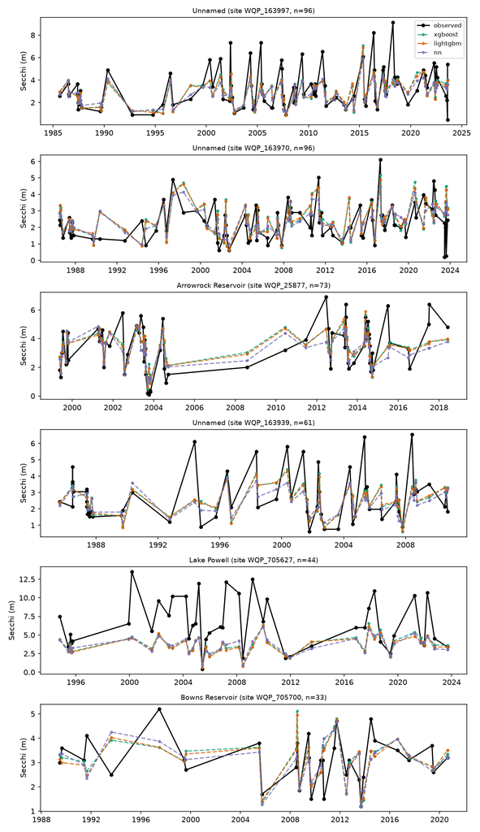

Example time series for a handful of longer-record test sites.

### SDD-weighting on the actual final config

The production config above already applies SDD-weighting (k=2.0) to both tree models, carrying forward v1's finding without re-litigating it at the time. Re-checked here directly on this report's own final 16-feature+shoreline_flag config (not an earlier candidate): XGBoost top-quartile RMSE improves 2.610→2.485m and top-quartile bias moves toward zero (−1.41→−1.20m), but overall RMSE gets worse, not better (1.813→1.839m, exactly matching the production table above), and overall bias moves further from zero (+0.153→+0.313m) as the "rest" group (73% of the data) degrades on both metrics. LightGBM shows the identical shape. Weighting is retained anyway, matching v1's own reasoning: a deliberate trade for tail accuracy, not a claim that it wins on every metric.

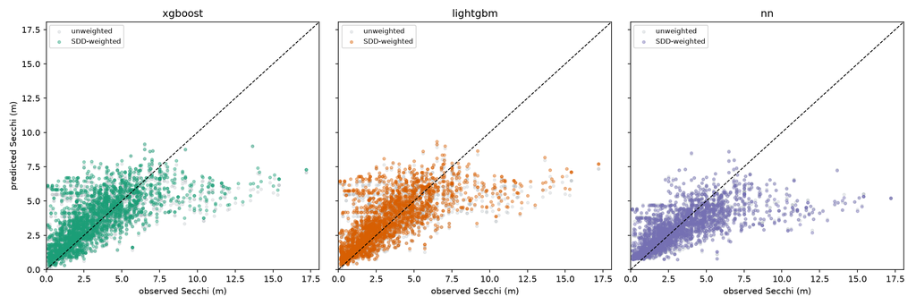

Predicted vs. observed, unweighted vs. SDD-weighted, on this report's final config.

v1 vs. v2, side by side

## What two threads closed out actually bought

Both changes requested at the end of v1 - gap-aware tuning applied systemically, and the shoreline-proximity flag - are now built, run end-to-end, and evaluated on the same untouched test partition v1 used. Net effect on the number that matters most:

| Model | v1 test RMSE | v2 test RMSE | Δ | v1 test bias | v2 test bias |
| --- | --- | --- | --- | --- | --- |
| XGBoost | 1.860 | 1.839 | −0.021 | +0.409 | +0.313 |
| LightGBM | 1.830 | 1.815 | −0.015 | +0.314 | +0.241 |
| Neural net | 1.839 | 1.888 | +0.049 | −0.143 | −0.297 |

Neither change was aimed at beating v1's single best-ever number in this project (XGBoost, optical+site+weather, pre-feature-selection, RMSE 1.747m) - that number was never reproduced by either version's own backward-elimination-and-final-tuning pipeline, v1's or v2's, because feature selection trades some of that richer configuration's raw accuracy for a smaller, more generalizable, cross-architecture-shared feature set. The relevant comparison is the two versions' own final, properly-gated production configs, and there v2 modestly improves on v1 for the two tree models while costing a bit of accuracy on the neural net.

[output not shown]

Next steps

## Two threads closed, two still open

This report closes out threads #3 and #4 from v1's next-steps list. Threads #1 and #2 stand as they were:

| # | Thread | Status |
| --- | --- | --- |
| 1 | Outlier-HUC investigation | done separately - see `outlier_investigation/report.html` |
| 2 | Train/val/test split sensitivity analysis | still open |
| 3 | Gap-aware tuning, applied systemically | done - this report |
| 4 | Shoreline-proximity flag | done - this report |

Thread #2 (split sensitivity) is now the more pressing of the two remaining threads: this report's own final-model callouts show, again, that a CV improvement doesn't reliably predict a test improvement (the neural net here; XGBoost's pre-elimination best in v1), and that partition 3/5 keep behaving like structurally different draws regardless of which feature set or tuning objective is used on top of them. Re-running evaluation under a different test-partition assignment, and separately under a different HUC4-to-partition random seed, would say whether that's a property of this specific 5-way split or of the basins themselves - a question neither v1 nor this report can answer on its own.